# R（一）

王宁宁

2015年10月23日

## 第1题

下列分别是某人7天linkedin和facebook 的访问次数：

```r
linkedin <- c(16, 9, 13, 5, 2, 17, 14)
facebook <- c(17, 7, 5, 16, 8, 13, 14)
```

求 哪天linkedin 访问次数超过15

```r
days<-c(1:7)
days[linkedin>15]
```

```
## [1] 1 6
```

求 哪天linkedin 访问次数少于15

```r
days[linkedin<15]
```

```
## [1] 2 3 4 5 7
```

求 哪天linkedin 的访问次数少于facebook

```r
days[linkedin<facebook]
```

```
## [1] 1 4 5
```

## 第2题

使用下列代码生成数列counts， 求第100个2出现在数列counts的第几个？

```r
set.seed(2111)
counts<-rpois(10000,lambda=1)
```

```r
table(counts)
```

```
## counts
##    0    1    2    3    4    5    6
## 3612 3734 1845  623  153   32    1
```

```r
which(counts==2)[100]
```

```
## [1] 580
```

## 第3题

使用下列语句生成数列xv，求离60最近的数是多少，在xv的第几个？

```r
set.seed(2111)
xv <- rnorm(10000,50,7)
```

```r
which(abs(xv-60)==min(abs(xv-60)))
```

```
## [1] 387
```

```r
xv[which(abs(xv-60)==min(abs(xv-60)))]
```

```
## [1] 60.00485
```

## 第4题

使用R程序建立下列数据表

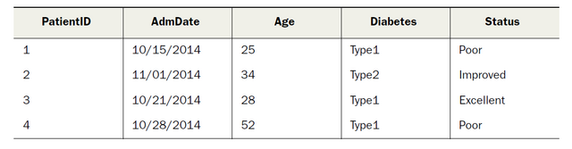

```r
patientID <- c(1, 2, 3, 4)
age <- c(25, 34, 28, 52)
diabetes <- c("Type1", "Type2", "Type1", "Type1")
AdmDate <- c("10/15/2014", "11/01/2014", "10/21/2014", "10/28/2014")
status <- c("Poor", "Improved", "Excellent", "Poor")
patientdata <- data.frame(patientID,AdmDate, age, diabetes, status)
patientdata
```

```
##   patientID    AdmDate age diabetes    status
## 1         1 10/15/2014  25    Type1      Poor
## 2         2 11/01/2014  34    Type2  Improved
## 3         3 10/21/2014  28    Type1 Excellent
## 4         4 10/28/2014  52    Type1      Poor
```

## 第5题

查看并读取num6-7.txt，要求 1）：重排数据，具体是首先按照Vegetation的字母升序排列，在每个Vegetation分类里，再按照Worm.density的降序排列.

```r
worms <- read.table("http://statstudy.github.io/data/num6-7.txt",header=T)
```

```r
attach(worms)
worms[order(Vegetation,-Worm.density),]
```

```
##           Field.Name Area Slope Vegetation Soil.pH  Damp Worm.density
## 2     Silwood.Bottom  5.1     2     Arable     5.2 FALSE            7
## 18        Pound.Hill  4.4     2     Arable     4.5 FALSE            5
## 8            Ashurst  2.1     0     Arable     4.8 FALSE            4
## 10     Rookery.Slope  1.5     4  Grassland     5.0  TRUE            7
## 1        Nashs.Field  3.6    11  Grassland     4.1 FALSE            4
## 7       Church.Field  3.5     3  Grassland     4.2 FALSE            3
## 3      Nursery.Field  2.8     3  Grassland     4.3 FALSE            2
## 6           Oak.Mead  3.1     2  Grassland     3.9 FALSE            2
## 13      South.Gravel  3.7     2  Grassland     4.0 FALSE            2
## 12      North.Gravel  3.3     1  Grassland     4.1 FALSE            1
## 19        Gravel.Pit  2.9     1  Grassland     3.5 FALSE            1
## 14 Observatory.Ridge  1.8     6  Grassland     3.8 FALSE            0
## 16      Water.Meadow  3.9     0     Meadow     4.9  TRUE            8
## 15        Pond.Field  4.1     0     Meadow     5.0  TRUE            6
## 4        Rush.Meadow  2.4     5     Meadow     4.9  TRUE            5
## 9        The.Orchard  1.9     0    Orchard     5.7 FALSE            9
## 11       Garden.Wood  2.9    10      Scrub     5.2 FALSE            8
## 5    Gunness.Thicket  3.8     0      Scrub     4.2 FALSE            6
## 17         Cheapside  2.2     8      Scrub     4.7  TRUE            4
## 20         Farm.Wood  0.8    10      Scrub     5.1  TRUE            3
```

2）：要求同上， 只是要按照Vegetation的字母降序，同时再每个Worm.density的升序排列。

```r
worms[order(-rank(Vegetation),Worm.density),]
```

```
##           Field.Name Area Slope Vegetation Soil.pH  Damp Worm.density
## 20         Farm.Wood  0.8    10      Scrub     5.1  TRUE            3
## 17         Cheapside  2.2     8      Scrub     4.7  TRUE            4
## 5    Gunness.Thicket  3.8     0      Scrub     4.2 FALSE            6
## 11       Garden.Wood  2.9    10      Scrub     5.2 FALSE            8
## 9        The.Orchard  1.9     0    Orchard     5.7 FALSE            9
## 4        Rush.Meadow  2.4     5     Meadow     4.9  TRUE            5
## 15        Pond.Field  4.1     0     Meadow     5.0  TRUE            6
## 16      Water.Meadow  3.9     0     Meadow     4.9  TRUE            8
## 14 Observatory.Ridge  1.8     6  Grassland     3.8 FALSE            0
## 12      North.Gravel  3.3     1  Grassland     4.1 FALSE            1
## 19        Gravel.Pit  2.9     1  Grassland     3.5 FALSE            1
## 3      Nursery.Field  2.8     3  Grassland     4.3 FALSE            2
## 6           Oak.Mead  3.1     2  Grassland     3.9 FALSE            2
## 13      South.Gravel  3.7     2  Grassland     4.0 FALSE            2
## 7       Church.Field  3.5     3  Grassland     4.2 FALSE            3
## 1        Nashs.Field  3.6    11  Grassland     4.1 FALSE            4
## 10     Rookery.Slope  1.5     4  Grassland     5.0  TRUE            7
## 8            Ashurst  2.1     0     Arable     4.8 FALSE            4
## 18        Pound.Hill  4.4     2     Arable     4.5 FALSE            5
## 2     Silwood.Bottom  5.1     2     Arable     5.2 FALSE            7
```

3）：继续使用num6-7.txt，要求对vegetation的不同分类，分别对Area，slope，soil.pH, worm.density分别求均值。

```r
aggregate(worms[,c(2,3,5,7)],by=list(Veg=Vegetation),mean)
```

```
##         Veg     Area    Slope  Soil.pH Worm.density
## 1    Arable 3.866667 1.333333 4.833333     5.333333
## 2 Grassland 2.911111 3.666667 4.100000     2.444444
## 3    Meadow 3.466667 1.666667 4.933333     6.333333
## 4   Orchard 1.900000 0.000000 5.700000     9.000000
## 5     Scrub 2.425000 7.000000 4.800000     5.250000
```

```r
detach(worms)
```

## 第6题

查看并加载library(MASS)的数据bacteria，要求按照trt中的不同类别，统计“y==n”的数目。(提示：trt有三个类别，要求输出一个长度为3的数列，第一个元素是“trt==placebo”中“y==n”的观测个数，以此类推)

```r
library(MASS)
with(bacteria,tapply((y=="n"),trt,sum))->aa;aa
```

```
## placebo    drug   drug+
##      12      18      13
```

## 第7题

根据下列数据表格，

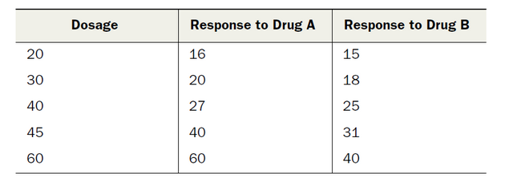

画出如下图形

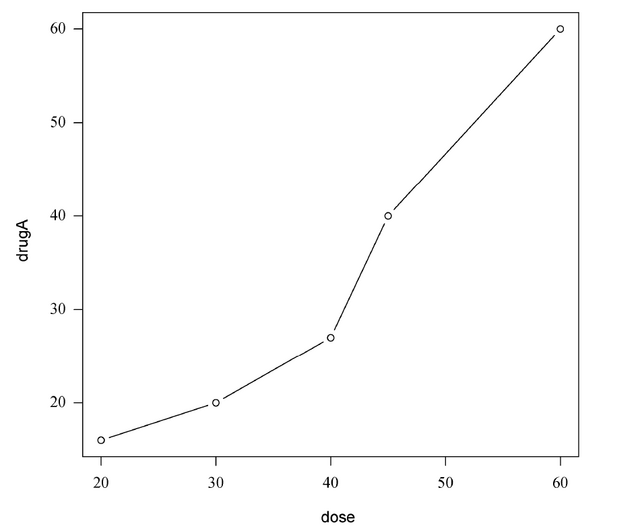

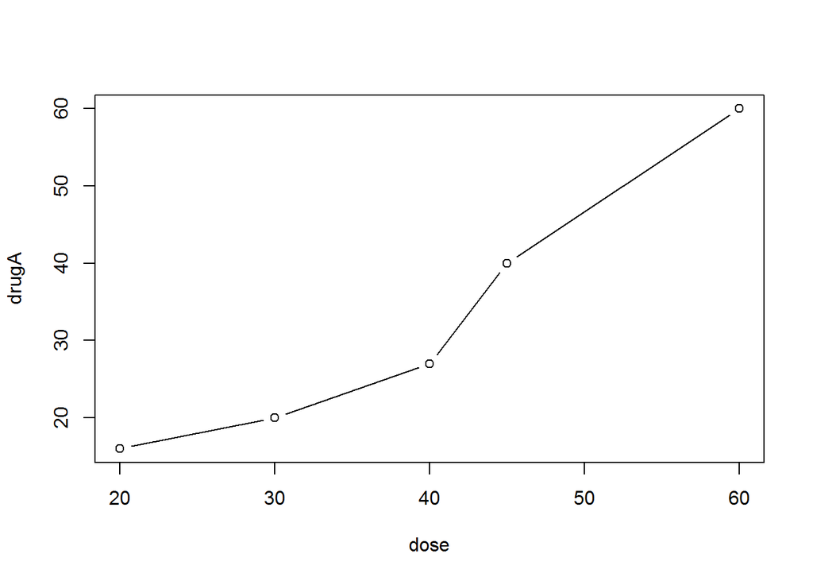

```r
dose <- c(20, 30, 40, 45, 60)
drugA <- c(16, 20, 27, 40, 60)
drugB <- c(15, 18, 25, 31, 40)
#win.graph(width = 13,height = 10,pointsize = 10)
plot(dose, drugA, type = "b")
```

## 第8题

使用下列代码建立leadership 数据集

```r
manager <- c(1, 2, 3, 4, 5)
date <- c("10/24/08", "10/28/08", "10/1/08", "10/12/08",
          "5/1/09")
gender <- c("M", "F", "F", "M", "F")
age <- c(82, 65, 25, 39, 99)
q1 <- c(5, 3, 3, 3, 2)
q2 <- c(4, 5, 5, 3, 2)
q3 <- c(5, 2, 5, 4, 1)
q4 <- c(5, 5, 5, NA, 2)
q5 <- c(5, 5, 2, NA, 1)
leadership <- data.frame(manager, date, gender, age, q1, q2, q3, q4, q5, stringsAsFactors = FALSE)
leadership
```

```
##   manager     date gender age q1 q2 q3 q4 q5
## 1       1 10/24/08      M  82  5  4  5  5  5
## 2       2 10/28/08      F  65  3  5  2  5  5
## 3       3  10/1/08      F  25  3  5  5  5  2
## 4       4 10/12/08      M  39  3  3  4 NA NA
## 5       5   5/1/09      F  99  2  2  1  2  1
```

请将99岁的年龄值重编码为缺失值

```r
leadership$age[leadership$age == 99] <- NA
leadership
```

```
##   manager     date gender age q1 q2 q3 q4 q5
## 1       1 10/24/08      M  82  5  4  5  5  5
## 2       2 10/28/08      F  65  3  5  2  5  5
## 3       3  10/1/08      F  25  3  5  5  5  2
## 4       4 10/12/08      M  39  3  3  4 NA NA
## 5       5   5/1/09      F  NA  2  2  1  2  1
```

新建立一个变量agecat： 大于75岁的为“Elder” 55岁到75岁之间的为“Middle age” 小于55岁的为“Young”

```r
leadership <- within(leadership,{
  agecat <- NA
  agecat[age > 75] <- "Elder"
  agecat[age >= 55 & age <= 75] <- "Middle Aged"
  agecat[age < 55] <- "Young" })
leadership
```

```
##   manager     date gender age q1 q2 q3 q4 q5      agecat
## 1       1 10/24/08      M  82  5  4  5  5  5       Elder
## 2       2 10/28/08      F  65  3  5  2  5  5 Middle Aged
## 3       3  10/1/08      F  25  3  5  5  5  2       Young
## 4       4 10/12/08      M  39  3  3  4 NA NA       Young
## 5       5   5/1/09      F  NA  2  2  1  2  1        <NA>
```

## 第9题

一组学生参加了数学、科学和英语考试。为了给所有学生确定一个单一的成绩衡量指，需要将前20%的学生评定为A，接下来20%的学生评定为B，依次类推。最后，需要按学生姓名字母顺序对学生排序。

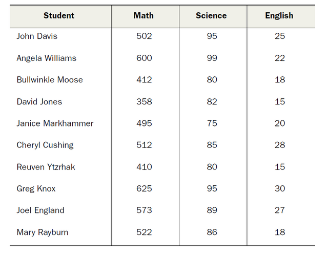

使用下列代码建立数据集

```r
Student <- c("John Davis", "Angela Williams",  "Bullwinkle Moose", "David Jones",   "Janice Markhammer", "Cheryl Cushing", "Reuven Ytzrhak", "Greg Knox", "Joel England", "Mary Rayburn")
Math <- c(502, 600, 412, 358, 495, 512, 410, 625, 573, 522)
Science <- c(95, 99, 80, 82, 75, 85, 80, 95, 89, 86)
English <- c(25, 22, 18, 15, 20, 28, 15, 30, 27, 18)
roster <- data.frame(Student, Math, Science, English, stringsAsFactors=FALSE)
roster
```

```
##              Student Math Science English
## 1         John Davis  502      95      25
## 2    Angela Williams  600      99      22
## 3   Bullwinkle Moose  412      80      18
## 4        David Jones  358      82      15
## 5  Janice Markhammer  495      75      20
## 6     Cheryl Cushing  512      85      28
## 7     Reuven Ytzrhak  410      80      15
## 8          Greg Knox  625      95      30
## 9       Joel England  573      89      27
## 10      Mary Rayburn  522      86      18
```

要求： 1) 为了评定成绩，先把每科成绩标准化，然后算出平均分。按照前20%的学生评定为A，接下来20%的学生评定为B。。。的规则算出总评成绩放入新的变量grade中 2) 增加两个变量Firstname 和 Lastname, 放入相应的值。（比如第一行：“John”是Firstname，“Davis” 是Lastname） 3）按照Firstname 和 Lastname的字母顺序对数据集进行排序

```r
z <- scale(roster[,2:4])
score <- apply(z, 1, mean)
roster <- cbind(roster, score)

y <- quantile(score, c(.8,.6,.4,.2))
roster$grade[score >= y[1]] <- "A"
roster$grade[score < y[1] & score >= y[2]] <- "B"
roster$grade[score < y[2] & score >= y[3]] <- "C"
roster$grade[score < y[3] & score >= y[4]] <- "D"
roster$grade[score < y[4]] <- "F"

name <- strsplit((roster$Student), " ")
lastname <- sapply(name, "[", 2)
firstname <- sapply(name, "[", 1)

roster <- cbind(firstname,lastname, roster[,-1])
roster <- roster[order(lastname,firstname),]

roster
```

```
##     firstname   lastname Math Science English      score grade
## 6      Cheryl    Cushing  512      85      28  0.3532485     C
## 1        John      Davis  502      95      25  0.5592028     B
## 9        Joel    England  573      89      27  0.6978361     B
## 4       David      Jones  358      82      15 -1.1620473     F
## 8        Greg       Knox  625      95      30  1.3378934     A
## 5      Janice Markhammer  495      75      20 -0.6289776     D
## 3  Bullwinkle      Moose  412      80      18 -0.8565414     D
## 10       Mary    Rayburn  522      86      18 -0.1768163     C
## 2      Angela   Williams  600      99      22  0.9238259     A
## 7      Reuven    Ytzrhak  410      80      15 -1.0476242     F
```

## 第10题

考虑R自带的数据集“mtcars”，使用`help(mtcars)`查看。试根据不同汽缸数（cyl）和不同档位数（gear）的组合计算平均里程（mpg）。

```r
attach(mtcars)
aggdata <-aggregate(mtcars,by=list(cyl,gear),FUN=mean, na.rm=TRUE)
aggdata[order(aggdata$mpg),c(4,12,3)]
```

```
##   cyl gear    mpg
## 3   8    3 15.050
## 8   8    5 15.400
## 7   6    5 19.700
## 2   6    3 19.750
## 5   6    4 19.750
## 1   4    3 21.500
## 4   4    4 26.925
## 6   4    5 28.200
```